# 01: Britain Data Processing

# Introduction

We believe the BirdTrack app had list-order tracking added during the 3.0.0 update (31 Jan 2019, or possibly the 3.1.0 update 7 Jun 2019), and removed during the 4.0.3 update (30 Aug 2022). This means that 2020 and 2021 are the only full years where mobile checklists are likely to be in list-entry order (https://apps.apple.com/gb/app/birdtrack/id596839218).

Load in relevant packages:

**Show code:**

```r
library(tidyverse)
library(RSQLite)
library(sf)
library(lutz)
library(suncalc)
library(remotes)
library(auk)

packageVersion("auk")
```

```
[1] '0.8.0'
```

**Show code:**

```r
source("CustomFunctions.R")
ls()
```

```
[1] "%notin%"      "expand_bbox"  "quiet_output"
```

**Show code:**

```r
source("FilePaths.R") # filepaths for (large) data files stored locally (file not provided to maintain double blind)
```

Produce shapefile boundary for Britain:

**Show code:**

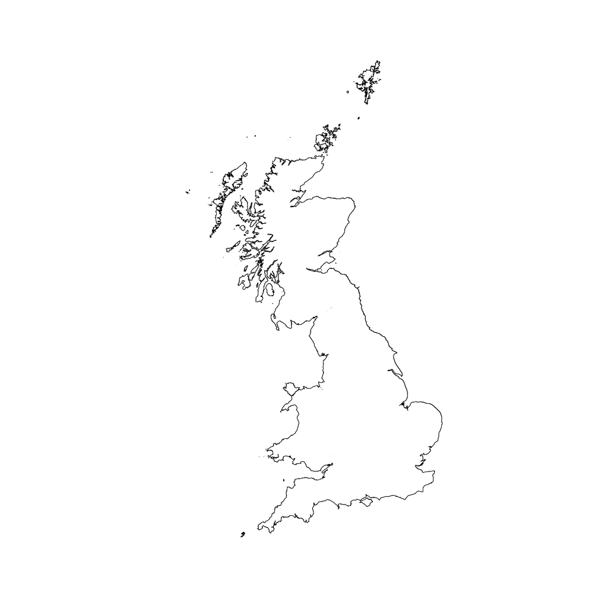

```r
Britain_sf <- read_sf("Data/Provided/bdline_gb.gpkg", layer = "country_region") %>%
  st_union() %>%
  st_transform(crs = 4326)

plot(Britain_sf)
```

Provide list of eBird users to remove:

**Show code:**

```r
observer_blacklist <- c("obs352263", "obs90515", "obs918130",
                        "obsr352263", "obsr90515", "obsr918130")
# note: seems to have been a recent change swapping between obsr and obs in format!
# observer_blacklist <- c()
```

Remove data from three users with aberrant unusual data patterns of eBird use - obs352263 (17,000 checklists in 2021, of which 15,000 either 5 or 10 minutes long), obs90515 (4,500 checklists in 2021, of which 2,500 5 minutes long, and possibly pseudo-standardised), and obs918130 (many unusual 2-species 1-minute checklists that may be due to an eBird bug).

# Data Processing

Read in and process BirdTrack data with a number of filters:

**Show code:**

```r
if (!file.exists("Data/BT_all.RData")) {
  # Set up SQL connection, read in SQL tables and produce 4 datasets:
  # locations, observations, taxonomy, and checklists
  BT_connection <- dbConnect(drv = SQLite(), dbname = BT_path)

  BT_tables <- dbListTables(BT_connection)
  BT_tables <- BT_tables[BT_tables != "sqlite_sequence"]

  BT_dataframes <- vector("list", length = length(BT_tables))

  for (i in seq(along = BT_tables)) {
    BT_dataframes[[i]] <- dbGetQuery(
      conn = BT_connection, statement = paste(
        "SELECT * FROM '", BT_tables[[i]], "'", sep = "")
    )
  }

  BT_locations <- BT_dataframes[[1]]
  BT_observations <- BT_dataframes[[2]]
  BT_taxonomy <- BT_dataframes[[3]]
  BT_checklists <- BT_dataframes[[4]]

  dbDisconnect(BT_connection)
  rm(BT_connection, BT_tables, BT_dataframes, i)

  # Filter locations to only those within the Britain region
  BT_locations <- BT_locations %>%
    select(locality_id = loc_id,
           locality_name = name,
           latitude,
           longitude) %>%
    st_as_sf(coords = c("longitude", "latitude"), crs = 4326, remove = FALSE) %>%
    mutate(in_area = as.logical(lengths(st_intersects(., Britain_sf)))) %>%
    st_drop_geometry() %>%
    filter(in_area == TRUE) %>%
    select(-in_area)

  # Filter checklists to only those from filtered locations, and then further filter to only
  # complete, mobile-uploaded, checklists from 2021, with duration between 1 minute and 5 hours
  BT_checklists <- BT_checklists %>%
    select(checklist_id = sub_id,
           creation_date = creation_dt,
           locality_id = loc_id,
           observer_id = user_code,
           observation_date = obs_date,
           observation_time = obs_time,
           duration_hours = duration_hrs,
           all_observations_reported = all_obs_reported,
           data_source = data_source) %>%
    filter(locality_id %in% BT_locations$locality_id) %>%
    mutate(creation_date = dmy_hms(creation_date),
           observation_date = dmy(observation_date),
           observation_time = hm(observation_time),
           duration_hours = as.numeric(duration_hours),
           duration_minutes = round(duration_hours * 60),
           all_observations_reported = as.logical(all_observations_reported)) %>%
    filter(year(creation_date) == 2021,
           year(observation_date) == 2021,
           duration_minutes >= 1,
           duration_minutes <= 300,
           all_observations_reported == TRUE,
           data_source == "M") %>%
    select(checklist_id, locality_id, observer_id, observation_date,
           observation_time, duration_minutes)

  # Filter checklists to remove nocturnal lists
  BT_checklists <- BT_checklists %>%
    left_join(., select(BT_locations, locality_id, latitude, longitude),
              by = "locality_id") %>%
    mutate(
      time_zone = tz_lookup_coords(lat = latitude, lon = longitude,
                                   method = "accurate"),
      date_time_start = as_datetime(observation_date + observation_time),
      date_time_end = date_time_start + minutes(duration_minutes),
      date_time_start_utc = force_tzs(date_time_start, tzones = time_zone),
      date_time_end_utc = date_time_start_utc + minutes(duration_minutes),
      overnight = date(date_time_start) != date(date_time_end)) %>%
    filter(overnight == FALSE) %>%
    select(-overnight) %>%
    mutate(
      altitude_start = (
        select(., date = date_time_start_utc, lat = latitude, lon = longitude) %>%
          getSunlightPosition(data = .) %>%
          pull(altitude)),
      altitude_end = (
        select(., date = date_time_end_utc, lat = latitude, lon = longitude) %>%
          getSunlightPosition(data = .) %>%
          pull(altitude)),
      diurnal = altitude_start > -6 * pi / 180 & altitude_end > -6 * pi / 180) %>%
    filter(diurnal == TRUE) %>%
    select(-c(time_zone, contains("date_time"), contains("altitude"), diurnal,
              latitude, longitude))

  # Filter observations to only those from filtered checklists, and only include
  # countable observations
  BT_observations <- BT_observations %>%
    select(checklist_id = sub_id,
           observation_id = obs_id,
           taxon_id = master_taxon_id,
           include_in_counting) %>%
    filter(checklist_id %in% BT_checklists$checklist_id,
           include_in_counting == 1) %>%
    select(-include_in_counting)

  # Run an equivalent to auk::auk_rollup() on the BirdTrack taxonomy (to coerce
  # observations below species level to species, and drop anything higher)
  BT_taxonomy <- BT_taxonomy %>%
    select(taxon_id = master_taxon_id,
           scientific_name,
           common_name = english_name,
           taxon_rank = taxon_rank_name,
           taxa) %>%
    mutate(species_binomial = if_else(
      taxon_rank == "Species", scientific_name, if_else(
        taxon_rank %in% c("Subspecies", "Subspecies (non-standard)",
                               "Variety"),
        word(scientific_name, 1, 2), NA)))

  # Join the four datasets together into an EBD-style dataset, and then filter to
  # only bird observations, drop observations above species level (and duplicated
  # subspecies observations), cut redundant columns, and append a checklist
  # richness column for later use
  BT_all <- reduce(list(BT_observations, BT_taxonomy,
                        BT_checklists, BT_locations),
                   left_join) %>%
    filter(taxa == "Birds") %>%
    arrange(observation_id) %>%
    mutate(scientific_name = species_binomial) %>%
    drop_na(scientific_name) %>%
    group_by(checklist_id, scientific_name) %>%
    filter(row_number() == 1) %>%
    ungroup() %>%
    select(observation_id, checklist_id, taxon_id, scientific_name,
           common_name, locality_id, locality_name, latitude, longitude,
           observer_id, observation_date, observation_time, duration_minutes) %>%
    group_by(checklist_id) %>%
    mutate(n_species = n_distinct(scientific_name)) %>%
    ungroup()

  BT_taxonomy <- BT_taxonomy %>%
    filter(taxon_rank == "Species",
           taxa == "Birds") %>%
    select(taxon_id, scientific_name, common_name)

  # Create zero-filled dataset (for later use):
  BT_zf <- BT_all %>%
    arrange(observation_id) %>%
    group_by(checklist_id) %>%
    mutate(obs_order = row_number()) %>%
    ungroup() %>%
    select(-c(observation_id, common_name, taxon_id)) %>%
    pivot_wider(names_from = scientific_name, values_from = obs_order, values_fill = NA) %>%
    pivot_longer(cols = unique(BT_all$scientific_name), names_to = "scientific_name", values_to = "obs_order") %>%
    left_join(., select(BT_taxonomy, taxon_id, scientific_name, common_name), by = "scientific_name") %>%
    arrange(checklist_id, taxon_id) %>%
    mutate(species_observed = !is.na(obs_order)) %>%
    select(obs_order, checklist_id, taxon_id, scientific_name, common_name,
           locality_id, locality_name, latitude, longitude,
           observer_id, observation_date, observation_time, duration_minutes,
           n_species, species_observed)

  # Check zero-fill has worked (should both be TRUE)
  n_distinct(BT_all$checklist_id) * n_distinct(BT_all$scientific_name) == nrow(BT_zf)
  sum(BT_zf$species_observed) == nrow(BT_all)

  # Create reporting rate dataset
  BT_rrs <- BT_zf %>%
    group_by(scientific_name) %>%
    summarise(reporting_rate = mean(species_observed))
  BT_breeding_rrs <- BT_zf %>%
    filter(month(observation_date) %in% 5:8) %>%
        group_by(scientific_name) %>%
    summarise(reporting_rate = mean(species_observed))

  save(BT_all, file = "Data/BT_all.RData")
  save(BT_locations, file = "Data/BT_locations.RData")
  save(BT_observations, file = "Data/BT_observations.RData")
  save(BT_taxonomy, file = "Data/BT_taxonomy.RData")
  save(BT_checklists, file = "Data/BT_checklists.RData")
  save(BT_zf, file = "Data/BT_zf.RData")
  save(BT_rrs, file = "Data/BT_rrs.RData")
  save(BT_breeding_rrs, file = "Data/BT_breeding_rrs.RData")

} else {
  load("Data/BT_all.RData")
  load("Data/BT_locations.RData")
  load("Data/BT_observations.RData")
  load("Data/BT_taxonomy.RData")
  load("Data/BT_checklists.RData")
  load("Data/BT_zf.RData")
  load("Data/BT_rrs.RData")
  load("Data/BT_breeding_rrs.RData")
}
```

Do the same with the eBird dataset:

**Show code:**

```r
if (!file.exists("Data/EB_all.RData")) {
  # Remove old versions, if they exist
  unlink("Data/ebd_relDec-2024_GBR.txt", force = TRUE)
  unlink("Data/ebd_sampling_relDec-2024_GBR.txt", force = TRUE)

  # Set up auk EBD pipeline, read in observations and checklists files, then process:
  auk_ebd(file = EB_obs_path,
          file_sampling = EB_sam_path) %>%
    auk_bbox(bbox = expand_bbox(st_bbox(Britain_sf))) %>%
    auk_year(year = 2021) %>%
    auk_duration(duration = c(1, 300)) %>%
    auk_distance(distance = c(0, 8)) %>%
    auk_protocol(protocol = c("Stationary", "Traveling")) %>%
    auk_exotic(exotic_code = c("", "N")) %>%
    auk_complete() %>%
    auk_filter(
      file = "Data/ebd_relDec-2024_GBR.txt",
      file_sampling = "Data/ebd_sampling_relDec-2024_GBR.txt",
      overwrite = TRUE)

  EB_observations <- read_ebd("Data/ebd_relDec-2024_GBR.txt",
                              unique = FALSE, rollup = FALSE) %>%
    auk_rollup(taxonomy_version = 2024, drop_higher = TRUE)
  EB_checklists <- read_sampling("Data/ebd_sampling_relDec-2024_GBR.txt",
                                 unique = FALSE)
  EB_taxonomy <- ebird_taxonomy
  EB_locations <- EB_checklists %>%
    select(latitude, longitude, locality_id, locality) %>%
    distinct()

  # Filter locations to only those within the Britain region
  EB_locations <- EB_locations %>%
    select(locality_id,
           locality_name = locality,
           latitude,
           longitude) %>%
    st_as_sf(coords = c("longitude", "latitude"), crs = 4326, remove = FALSE) %>%
    mutate(in_area = as.logical(lengths(st_intersects(., Britain_sf)))) %>%
    st_drop_geometry() %>%
    filter(in_area == TRUE) %>%
    select(-in_area)

  # Filter checklists to only those from filtered locations
  EB_checklists <- EB_checklists %>%
    select(checklist_id = sampling_event_identifier,
           locality_id,
           observer_id,
           observation_date,
           observation_time = time_observations_started,
           duration_minutes,
           all_observations_reported = all_species_reported) %>%
    filter(locality_id %in% EB_locations$locality_id,
           observer_id %notin% observer_blacklist) %>%
    mutate(observation_date = ymd(observation_date),
           observation_time = hms(observation_time),
           duration_minutes = as.integer(duration_minutes)) %>%
    select(checklist_id, locality_id, observer_id, observation_date,
           observation_time, duration_minutes)

  # Filter checklists to remove nocturnal lists (use code from eBird analysis)
  EB_checklists <- EB_checklists %>%
    left_join(., select(EB_locations, locality_id, latitude, longitude),
              by = "locality_id") %>%
    mutate(
      time_zone = tz_lookup_coords(lat = latitude, lon = longitude,
                                   method = "accurate"),
      date_time_start = as_datetime(observation_date + observation_time),
      date_time_end = date_time_start + minutes(duration_minutes),
      date_time_start_utc = force_tzs(date_time_start, tzones = time_zone),
      date_time_end_utc = date_time_start_utc + minutes(duration_minutes),
      overnight = date(date_time_start) != date(date_time_end)) %>%
    filter(overnight == FALSE) %>%
    select(-overnight) %>%
    mutate(
      altitude_start = (
        select(., date = date_time_start_utc, lat = latitude, lon = longitude) %>%
          getSunlightPosition(data = .) %>%
          pull(altitude)),
      altitude_end = (
        select(., date = date_time_end_utc, lat = latitude, lon = longitude) %>%
          getSunlightPosition(data = .) %>%
          pull(altitude)),
      diurnal = altitude_start > -6 * pi / 180 & altitude_end > -6 * pi / 180) %>%
    filter(diurnal == TRUE) %>%
    select(-c(time_zone, contains("date_time"), contains("altitude"), diurnal),
           latitude, longitude)

  # Filter observations to only those from filtered checklists
  EB_observations <- EB_observations %>%
    select(checklist_id = sampling_event_identifier,
           observation_id = global_unique_identifier,
           scientific_name) %>%
    filter(checklist_id %in% EB_checklists$checklist_id)

  # Modify taxonomy
  EB_taxonomy <- EB_taxonomy %>%
    filter(category == "species") %>%
    select(taxon_id = taxon_order,
           scientific_name,
           common_name)

  # Join the four datasets together into an EBD-style dataset, cut redundant
  # columns, and append a checklist richness column for later use
  EB_all <- reduce(list(EB_observations, EB_taxonomy,
                        EB_checklists, EB_locations),
                   left_join) %>%
    arrange(observation_id) %>%
    select(observation_id, checklist_id, taxon_id, scientific_name,
           common_name, locality_id, locality_name, latitude, longitude,
           observer_id, observation_date, observation_time, duration_minutes) %>%
    group_by(checklist_id) %>%
    mutate(n_species = n_distinct(scientific_name)) %>%
    ungroup()

  # Create zero-filled dataset (for later use):
  EB_zf <- EB_all %>%
    arrange(observation_id) %>%
    group_by(checklist_id) %>%
    mutate(obs_order = row_number()) %>%
    ungroup() %>%
    select(-c(observation_id, common_name, taxon_id)) %>%
    pivot_wider(names_from = scientific_name, values_from = obs_order, values_fill = NA) %>%
    pivot_longer(cols = unique(EB_all$scientific_name), names_to = "scientific_name", values_to = "obs_order") %>%
    left_join(., select(EB_taxonomy, taxon_id, scientific_name, common_name), by = "scientific_name") %>%
    arrange(checklist_id, taxon_id) %>%
    mutate(species_observed = !is.na(obs_order)) %>%
    select(obs_order, checklist_id, taxon_id, scientific_name, common_name,
           locality_id, locality_name, latitude, longitude,
           observer_id, observation_date, observation_time, duration_minutes,
           n_species, species_observed)

  # Check zero-fill has worked (should both be TRUE)
  n_distinct(EB_all$checklist_id) * n_distinct(EB_all$scientific_name) == nrow(EB_zf)
  sum(EB_zf$species_observed) == nrow(EB_all)

  # Create reporting rate dataset
  EB_rrs <- EB_zf %>%
    group_by(scientific_name) %>%
    summarise(reporting_rate = mean(species_observed))
  EB_breeding_rrs <- EB_zf %>%
    filter(month(observation_date) %in% 5:8) %>%
        group_by(scientific_name) %>%
    summarise(reporting_rate = mean(species_observed))

  save(EB_all, file = "Data/EB_all.RData")
  save(EB_locations, file = "Data/EB_locations.RData")
  save(EB_observations, file = "Data/EB_observations.RData")
  save(EB_taxonomy, file = "Data/EB_taxonomy.RData")
  save(EB_checklists, file = "Data/EB_checklists.RData")
  save(EB_zf, file = "Data/EB_zf.RData")
  save(EB_rrs, file = "Data/EB_rrs.RData")
  save(EB_breeding_rrs, file = "Data/EB_breeding_rrs.RData")

} else {
  load("Data/EB_all.RData")
  load("Data/EB_locations.RData")
  load("Data/EB_observations.RData")
  load("Data/EB_taxonomy.RData")
  load("Data/EB_checklists.RData")
  load("Data/EB_zf.RData")
  load("Data/EB_rrs.RData")
  load("Data/EB_breeding_rrs.RData")
}
```

Look at the outputs:

**Show code:**

```r
str(BT_all)
```

```
tibble [1,316,710 × 14] (S3: tbl_df/tbl/data.frame)
 $ observation_id  : chr [1:1316710] "OBS296824760" "OBS296824761" "OBS296824762" "OBS296824763" ...
 $ checklist_id    : chr [1:1316710] "SUB42429572" "SUB42429572" "SUB42429572" "SUB42429572" ...
 $ taxon_id        : int [1:1316710] 371 449 450 453 270 271 342 471 457 436 ...
 $ scientific_name : chr [1:1316710] "Turdus merula" "Garrulus glandarius" "Pica pica" "Coloeus monedula" ...
 $ common_name     : chr [1:1316710] "Blackbird" "Jay" "Magpie" "Jackdaw" ...
 $ locality_id     : chr [1:1316710] "LOC1962341" "LOC1962341" "LOC1962341" "LOC1962341" ...
 $ locality_name   : chr [1:1316710] "Norwich NR4" "Norwich NR4" "Norwich NR4" "Norwich NR4" ...
 $ latitude        : num [1:1316710] 52.6 52.6 52.6 52.6 52.6 ...
 $ longitude       : num [1:1316710] 1.27 1.27 1.27 1.27 1.27 ...
 $ observer_id     : chr [1:1316710] "U15189" "U15189" "U15189" "U15189" ...
 $ observation_date: Date[1:1316710], format: "2021-01-01" "2021-01-01" ...
 $ observation_time:Formal class 'Period' [package "lubridate"] with 6 slots
  .. ..@ .Data : num [1:1316710] 0 0 0 0 0 0 0 0 0 0 ...
  .. ..@ year  : num [1:1316710] 0 0 0 0 0 0 0 0 0 0 ...
  .. ..@ month : num [1:1316710] 0 0 0 0 0 0 0 0 0 0 ...
  .. ..@ day   : num [1:1316710] 0 0 0 0 0 0 0 0 0 0 ...
  .. ..@ hour  : num [1:1316710] 8 8 8 8 8 8 8 8 8 8 ...
  .. ..@ minute: num [1:1316710] 30 30 30 30 30 30 30 30 30 30 ...
 $ duration_minutes: num [1:1316710] 10 10 10 10 10 10 10 10 10 10 ...
 $ n_species       : int [1:1316710] 11 11 11 11 11 11 11 11 11 11 ...
```

**Show code:**

```r
str(BT_zf)
```

```
tibble [24,895,284 × 15] (S3: tbl_df/tbl/data.frame)
 $ obs_order       : int [1:24895284] NA NA NA NA NA NA NA NA NA NA ...
 $ checklist_id    : chr [1:24895284] "SUB42429572" "SUB42429572" "SUB42429572" "SUB42429572" ...
 $ taxon_id        : int [1:24895284] 1 2 3 4 5 6 7 8 9 10 ...
 $ scientific_name : chr [1:24895284] "Gavia stellata" "Gavia arctica" "Gavia immer" "Gavia adamsii" ...
 $ common_name     : chr [1:24895284] "Red-throated Diver" "Black-throated Diver" "Great Northern Diver" "White-billed Diver" ...
 $ locality_id     : chr [1:24895284] "LOC1962341" "LOC1962341" "LOC1962341" "LOC1962341" ...
 $ locality_name   : chr [1:24895284] "Norwich NR4" "Norwich NR4" "Norwich NR4" "Norwich NR4" ...
 $ latitude        : num [1:24895284] 52.6 52.6 52.6 52.6 52.6 ...
 $ longitude       : num [1:24895284] 1.27 1.27 1.27 1.27 1.27 ...
 $ observer_id     : chr [1:24895284] "U15189" "U15189" "U15189" "U15189" ...
 $ observation_date: Date[1:24895284], format: "2021-01-01" "2021-01-01" ...
 $ observation_time:Formal class 'Period' [package "lubridate"] with 6 slots
  .. ..@ .Data : num [1:24895284] 0 0 0 0 0 0 0 0 0 0 ...
  .. ..@ year  : num [1:24895284] 0 0 0 0 0 0 0 0 0 0 ...
  .. ..@ month : num [1:24895284] 0 0 0 0 0 0 0 0 0 0 ...
  .. ..@ day   : num [1:24895284] 0 0 0 0 0 0 0 0 0 0 ...
  .. ..@ hour  : num [1:24895284] 8 8 8 8 8 8 8 8 8 8 ...
  .. ..@ minute: num [1:24895284] 30 30 30 30 30 30 30 30 30 30 ...
 $ duration_minutes: num [1:24895284] 10 10 10 10 10 10 10 10 10 10 ...
 $ n_species       : int [1:24895284] 11 11 11 11 11 11 11 11 11 11 ...
 $ species_observed: logi [1:24895284] FALSE FALSE FALSE FALSE FALSE FALSE ...
```

**Show code:**

```r
str(BT_rrs)
```

```
tibble [394 × 2] (S3: tbl_df/tbl/data.frame)
 $ scientific_name: chr [1:394] "Acanthis cabaret" "Acanthis flammea" "Acanthis hornemanni" "Accipiter gentilis" ...
 $ reporting_rate : num [1:394] 3.32e-02 5.22e-04 1.58e-05 3.20e-03 7.80e-02 ...
```

**Show code:**

```r
str(BT_breeding_rrs)
```

```
tibble [394 × 2] (S3: tbl_df/tbl/data.frame)
 $ scientific_name: chr [1:394] "Acanthis cabaret" "Acanthis flammea" "Acanthis hornemanni" "Accipiter gentilis" ...
 $ reporting_rate : num [1:394] 0.02165 0.000279 0 0.002561 0.054521 ...
```

**Show code:**

```r
str(EB_all)
```

```
tibble [3,600,798 × 14] (S3: tbl_df/tbl/data.frame)
 $ observation_id  : chr [1:3600798] "URN:CornellLabOfOrnithology:EBIRD:OBS1040702869" "URN:CornellLabOfOrnithology:EBIRD:OBS1040702870" "URN:CornellLabOfOrnithology:EBIRD:OBS1040702871" "URN:CornellLabOfOrnithology:EBIRD:OBS1040702872" ...
 $ checklist_id    : chr [1:3600798] "S78355793" "S78355793" "S78355793" "S78355793" ...
 $ taxon_id        : num [1:3600798] 330 21351 21243 28986 1817 ...
 $ scientific_name : chr [1:3600798] "Branta canadensis" "Corvus corone" "Pica pica" "Erithacus rubecula" ...
 $ common_name     : chr [1:3600798] "Canada Goose" "Carrion Crow" "Eurasian Magpie" "European Robin" ...
 $ locality_id     : chr [1:3600798] "L10186545" "L10186545" "L10186545" "L10186545" ...
 $ locality_name   : chr [1:3600798] "Wanstead Flats--Bush Wood" "Wanstead Flats--Bush Wood" "Wanstead Flats--Bush Wood" "Wanstead Flats--Bush Wood" ...
 $ latitude        : num [1:3600798] 51.6 51.6 51.6 51.6 51.6 ...
 $ longitude       : num [1:3600798] 0.0206 0.0206 0.0206 0.0206 0.0206 ...
 $ observer_id     : chr [1:3600798] "obsr1292453" "obsr1292453" "obsr1292453" "obsr1292453" ...
 $ observation_date: Date[1:3600798], format: "2021-01-01" "2021-01-01" ...
 $ observation_time:Formal class 'Period' [package "lubridate"] with 6 slots
  .. ..@ .Data : num [1:3600798] 0 0 0 0 0 0 0 0 0 0 ...
  .. ..@ year  : num [1:3600798] 0 0 0 0 0 0 0 0 0 0 ...
  .. ..@ month : num [1:3600798] 0 0 0 0 0 0 0 0 0 0 ...
  .. ..@ day   : num [1:3600798] 0 0 0 0 0 0 0 0 0 0 ...
  .. ..@ hour  : num [1:3600798] 8 8 8 8 8 8 8 7 7 7 ...
  .. ..@ minute: num [1:3600798] 0 0 0 0 0 0 0 35 35 35 ...
 $ duration_minutes: int [1:3600798] 6 6 6 6 6 6 6 5 5 5 ...
 $ n_species       : int [1:3600798] 12 12 12 12 12 12 12 8 8 8 ...
```

**Show code:**

```r
str(EB_zf)
```

```
tibble [66,531,912 × 15] (S3: tbl_df/tbl/data.frame)
 $ obs_order       : int [1:66531912] NA NA 11 NA NA NA NA NA NA NA ...
 $ checklist_id    : chr [1:66531912] "S100000681" "S100000681" "S100000681" "S100000681" ...
 $ taxon_id        : num [1:66531912] 257 261 264 276 290 294 299 302 310 319 ...
 $ scientific_name : chr [1:66531912] "Anser caerulescens" "Anser rossii" "Anser anser" "Anser albifrons" ...
 $ common_name     : chr [1:66531912] "Snow Goose" "Ross's Goose" "Graylag Goose" "Greater White-fronted Goose" ...
 $ locality_id     : chr [1:66531912] "L1235272" "L1235272" "L1235272" "L1235272" ...
 $ locality_name   : chr [1:66531912] "South Downs NP--Pulborough Brooks RSPB Reserve" "South Downs NP--Pulborough Brooks RSPB Reserve" "South Downs NP--Pulborough Brooks RSPB Reserve" "South Downs NP--Pulborough Brooks RSPB Reserve" ...
 $ latitude        : num [1:66531912] 50.9 50.9 50.9 50.9 50.9 ...
 $ longitude       : num [1:66531912] -0.493 -0.493 -0.493 -0.493 -0.493 ...
 $ observer_id     : chr [1:66531912] "obsr1540243" "obsr1540243" "obsr1540243" "obsr1540243" ...
 $ observation_date: Date[1:66531912], format: "2021-12-29" "2021-12-29" ...
 $ observation_time:Formal class 'Period' [package "lubridate"] with 6 slots
  .. ..@ .Data : num [1:66531912] 0 0 0 0 0 0 0 0 0 0 ...
  .. ..@ year  : num [1:66531912] 0 0 0 0 0 0 0 0 0 0 ...
  .. ..@ month : num [1:66531912] 0 0 0 0 0 0 0 0 0 0 ...
  .. ..@ day   : num [1:66531912] 0 0 0 0 0 0 0 0 0 0 ...
  .. ..@ hour  : num [1:66531912] 9 9 9 9 9 9 9 9 9 9 ...
  .. ..@ minute: num [1:66531912] 4 4 4 4 4 4 4 4 4 4 ...
 $ duration_minutes: int [1:66531912] 106 106 106 106 106 106 106 106 106 106 ...
 $ n_species       : int [1:66531912] 26 26 26 26 26 26 26 26 26 26 ...
 $ species_observed: logi [1:66531912] FALSE FALSE TRUE FALSE FALSE FALSE ...
```

**Show code:**

```r
str(EB_rrs)
```

```
tibble [388 × 2] (S3: tbl_df/tbl/data.frame)
 $ scientific_name: chr [1:388] "Acanthis flammea" "Accipiter nisus" "Acrocephalus agricola" "Acrocephalus arundinaceus" ...
 $ reporting_rate : num [1:388] 2.87e-02 8.29e-02 5.83e-06 4.20e-04 1.52e-04 ...
```

**Show code:**

```r
str(EB_breeding_rrs)
```

```
tibble [388 × 2] (S3: tbl_df/tbl/data.frame)
 $ scientific_name: chr [1:388] "Acanthis flammea" "Accipiter nisus" "Acrocephalus agricola" "Acrocephalus arundinaceus" ...
 $ reporting_rate : num [1:388] 1.91e-02 6.63e-02 1.85e-05 1.33e-03 3.71e-04 ...
```

Generate lists of species to model later:

**Show code:**

```r
fullyear_common <- left_join(BT_rrs, EB_rrs, by = "scientific_name") %>%
  filter(reporting_rate.x > 0.01,
         reporting_rate.y > 0.01) %>%
  pull(scientific_name)

breeding_common <- left_join(BT_breeding_rrs, EB_breeding_rrs, by = "scientific_name") %>%
  filter(reporting_rate.x > 0.01,
         reporting_rate.y > 0.01,
         scientific_name %in% fullyear_common) %>%
  pull(scientific_name)

save(fullyear_common, file = "Data/fullyear_common.RData")
save(breeding_common, file = "Data/breeding_common.RData")

paste(length(fullyear_common), "common species in full year dataset")
```

```
[1] "146 common species in full year dataset"
```

**Show code:**

```r
paste(length(breeding_common), "common species in breeding season dataset")
```

```
[1] "132 common species in breeding season dataset"
```

Process eBird data again, with different filters - for supplementary analysis of incomplete:complete species preferences (following Johnston et al. 2023):

**Show code:**

```r
if (!file.exists("Data/supp_ebd_relDec-2024_GBR.txt")) {
  auk_ebd(file = EB_obs_path,
          file_sampling = EB_sam_path) %>%
    auk_bbox(bbox = expand_bbox(st_bbox(Britain_sf))) %>%
    auk_year(year = 2021) %>%
    auk_exotic(exotic_code = c("", "N")) %>%
    auk_filter(
      file = "Data/supp_ebd_relDec-2024_GBR.txt",
      file_sampling = "Data/supp_ebd_sampling_relDec-2024_GBR.txt",
      overwrite = TRUE)
}
```